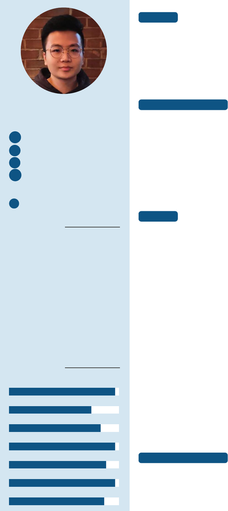

教育背景

2018-2020 硕士 乔治城大学 华盛顿特区，美国

专业: 数学统计与数据科学

GPA: 3.7/4

曾担任本专业机器学习助教; 曾担任数学辅导员

2014-2018 学士 中国农业大学 北京，中国

专业: 数学与应用数学

GPA: 3.6/4

曾担任本专业概率统计助教; 曾获得校级三等奖学金

项目经历 & 个人博客

2019 年 5 月 深度学习算法在谷歌公司股价预测上的应用

2019 年 8 月 机器学习在犯罪分析学中的玻璃碎片识别上的应用

2020 年 1 月 卷积神经网络在图像识别上的应用

2020 年 4 月 基于 XGBo ost 算法的驾驶员的安全性风险分析与预测

2020 年 6 月 关于 COVID-19 (新冠病毒) 的数据分析、挖掘、可视化以及短期预测

2020 年 7 月 基于深度学习算法的癌症患者 30 天再入院率分析与预测

2020 年 3 月至今

• 你好，Julia

• 逻辑回归中的数学 vs. 编程

• 机器学习算法整理、面经以及应用

• TensorFlow 2.0 中的人工神经网络在数字识别上的应用

• 卷积神经网络在人脸识别上的应用

工作经历

2018-2019 上海简雍资产管理有限公司 数据挖掘实习生

• 主要工作: 参与对公司的股价预测系统在 XGBoost 模型上的改

进，并独立完成不同模型之间的评估对比工作。

• 数据预处理: 使用 Python 从万德数据库调用金融数据，并用 SQL

对数据进行转换，清洗和筛选。对数据做归一化、标准化。

• 数据可视化: 对影响目标公司股价和股息分配的排名前十的特

征用 Tableau 做气泡图以及概率分布图进行可视化，并且使用

Seaborn 以及 plotly 对数据排名前五的特征做散点回归统计图。

• 数据建模: 利用 XGRegressor、ANN 等机器学习算法对公司股

价、股息分配进行回归并预测，测试集的预测准确率达到 0.87，

并且趋势拟合基本与原数据一致，且有不错的泛化能力。

• 模型评估: 成功预测接下来的半个月股息变化趋势并在测试集上

使得均方误差达到 1.214、平均绝对百分比误差达到 0.006，并帮

助量化团队的 CTA 策略在 BigQuant 量化大赛上斩获二等奖。

2017-2018 上海中融汇信期货有限公司 量化研究实习生

• 主要工作: 参与构建深度神经网络模型来预测客户的违约情况以

及破产预测，并独立完成神经网络的数据预处理和参数调节工作。

• 数据预处理: 使用 Python 调取本公司的客户数据并进行缺失值

填充、特征分析、数据清洗。使用 SQL 对 50000+ 观测数的客户

数据进行分组、筛选、数据库连接整合以及数据透视转换。

• 数据建模: 构建逻辑回归、支持向量机以及随机森林等传统机器

学习算法模型对数据建模以供和深度学习算法来进行对比。

• 模型评估: 对模型的表现进行评估，深度神经网络在测试集上的

分类误差减小到 0.09, 分类准确度达到 0.89、AUC 达到 0.92、敏

感度和特异度都达到 0.83，帮助公司减少了 150000+ 人民币的

来自客户违约风险的损失。

技能资格 & 个人爱好

• 语言能力: CET-6，托福总分 103，GRE 总分 323

• 资格证书: 证券、期货从业资格证

• 个人爱好: 演讲、篮球、书法、电子科技

高子敬

数据科学工程师

i 1996 年 8 月 8 日

B 浦东新区，上海市，中国

T 18616531215

m 1. 个人网站

2. 领英

3. Github

@ gzj18616531215@outlook.com

自我评价

三年以上数据整合、清洗、转换以及分

析经验

五年以上 Python、R 以及 SQL 编程

经验

三年以上机器学习、深度学习框架搭

建、模型评估以及云计算经验

曾参与深度学习框架在股价预测和破产

分析领域中的建模和调参工作；主要负

责百万级数据量的人脸识别系统模型构

建和评估工作。

我理解的数据科学就是洞察人性的过

程，数据只不过是把用户的需求，用量

化的方式表达出来。

专业能力

思维、表达以及沟通能力

编程语言（Python、R、MATLAB）

深度学习框架（TensorFlow、PyTorch）

机器学习算法（SVM、XGBo ost 等）

关系数据库（MySQL、PostgreSQL）

云计算（Spark、Hadoop）

数据可视化（Tableau、Seaborn）